# Diabetes Risks Predictions

Seif Kungulio

## Business Understanding

### Business Objective

The primary business objective of this project is to support the **Texas Department of State Health Services** in enhancing diabetes prevention efforts across the state. By leveraging self-reported health behavior and demographic data, the goal is to develop a predictive model by **2026** that identifies **Texas adults with a 30% or higher risk** of developing diabetes within the next five years. This model aims to facilitate **early detection**, reduce **long-term healthcare costs**, promote **health equity**, and **optimize resource allocation** in vulnerable communities.

### Problem Statement

How can public health agencies in Texas use self-reported behavioral and demographic data to **identify adults at 30%+ risk of developing diabetes within 5 years**, using markers like **HbA1c (>5.7%)** and **BMI (>30)**, and implement targeted interventions by **2026**?.

### Business Success Criteria

The project will be considered successful if it:

- Produces a validated predictive model with practical thresholds for decision-making
- Demonstrates improved identification of high-risk populations compared to current screening protocols
- Supports targeted outreach that aligns with state health equity goals
- Provides actionable insights for stakeholders through dashboards or visual summaries

## Data Understanding

### Data Collection

The primary dataset used is the **Diabetes Health Indicators Dataset** sourced from **Kaggle**, based on the **2015 Behavioral Risk Factor Surveillance System (BRFSS)**. This dataset includes over **253,000 observations** and **22 attributes**, offering a rich foundation for predictive modeling using demographic, behavioral, and clinical health indicators.

### Load the data

```r
diabetes.df <- read.csv("diabetes_health_indicators_BRFSS2015.csv")
```

### Check for dimension and structure

```r
dim(diabetes.df)
```

```
## [1] 253680     22
```

```r
str(diabetes.df)
```

```
## 'data.frame':    253680 obs. of  22 variables:
##  $ Diabetes_binary     : num  0 0 0 0 0 0 0 0 1 0 ...
##  $ HighBP              : num  1 0 1 1 1 1 1 1 1 0 ...
##  $ HighChol            : num  1 0 1 0 1 1 0 1 1 0 ...
##  $ CholCheck           : num  1 0 1 1 1 1 1 1 1 1 ...
##  $ BMI                 : num  40 25 28 27 24 25 30 25 30 24 ...
##  $ Smoker              : num  1 1 0 0 0 1 1 1 1 0 ...
##  $ Stroke              : num  0 0 0 0 0 0 0 0 0 0 ...
##  $ HeartDiseaseorAttack: num  0 0 0 0 0 0 0 0 1 0 ...
##  $ PhysActivity        : num  0 1 0 1 1 1 0 1 0 0 ...
##  $ Fruits              : num  0 0 1 1 1 1 0 0 1 0 ...
##  $ Veggies             : num  1 0 0 1 1 1 0 1 1 1 ...
##  $ HvyAlcoholConsump   : num  0 0 0 0 0 0 0 0 0 0 ...
##  $ AnyHealthcare       : num  1 0 1 1 1 1 1 1 1 1 ...
##  $ NoDocbcCost         : num  0 1 1 0 0 0 0 0 0 0 ...
##  $ GenHlth             : num  5 3 5 2 2 2 3 3 5 2 ...
##  $ MentHlth            : num  18 0 30 0 3 0 0 0 30 0 ...
##  $ PhysHlth            : num  15 0 30 0 0 2 14 0 30 0 ...
##  $ DiffWalk            : num  1 0 1 0 0 0 0 1 1 0 ...
##  $ Sex                 : num  0 0 0 0 0 1 0 0 0 1 ...
##  $ Age                 : num  9 7 9 11 11 10 9 11 9 8 ...
##  $ Education           : num  4 6 4 3 5 6 6 4 5 4 ...
##  $ Income              : num  3 1 8 6 4 8 7 4 1 3 ...
```

### Check for statistical summary

```r
summary(diabetes.df)
```

```
##  Diabetes_binary      HighBP         HighChol        CholCheck
##  Min.   :0.0000   Min.   :0.000   Min.   :0.0000   Min.   :0.0000
##  1st Qu.:0.0000   1st Qu.:0.000   1st Qu.:0.0000   1st Qu.:1.0000
##  Median :0.0000   Median :0.000   Median :0.0000   Median :1.0000
##  Mean   :0.1393   Mean   :0.429   Mean   :0.4241   Mean   :0.9627
##  3rd Qu.:0.0000   3rd Qu.:1.000   3rd Qu.:1.0000   3rd Qu.:1.0000
##  Max.   :1.0000   Max.   :1.000   Max.   :1.0000   Max.   :1.0000
##       BMI            Smoker           Stroke        HeartDiseaseorAttack
##  Min.   :12.00   Min.   :0.0000   Min.   :0.00000   Min.   :0.00000
##  1st Qu.:24.00   1st Qu.:0.0000   1st Qu.:0.00000   1st Qu.:0.00000
##  Median :27.00   Median :0.0000   Median :0.00000   Median :0.00000
##  Mean   :28.38   Mean   :0.4432   Mean   :0.04057   Mean   :0.09419
##  3rd Qu.:31.00   3rd Qu.:1.0000   3rd Qu.:0.00000   3rd Qu.:0.00000
##  Max.   :98.00   Max.   :1.0000   Max.   :1.00000   Max.   :1.00000
##   PhysActivity        Fruits          Veggies       HvyAlcoholConsump
##  Min.   :0.0000   Min.   :0.0000   Min.   :0.0000   Min.   :0.0000
##  1st Qu.:1.0000   1st Qu.:0.0000   1st Qu.:1.0000   1st Qu.:0.0000
##  Median :1.0000   Median :1.0000   Median :1.0000   Median :0.0000
##  Mean   :0.7565   Mean   :0.6343   Mean   :0.8114   Mean   :0.0562
##  3rd Qu.:1.0000   3rd Qu.:1.0000   3rd Qu.:1.0000   3rd Qu.:0.0000
##  Max.   :1.0000   Max.   :1.0000   Max.   :1.0000   Max.   :1.0000
##  AnyHealthcare     NoDocbcCost         GenHlth         MentHlth
##  Min.   :0.0000   Min.   :0.00000   Min.   :1.000   Min.   : 0.000
##  1st Qu.:1.0000   1st Qu.:0.00000   1st Qu.:2.000   1st Qu.: 0.000
##  Median :1.0000   Median :0.00000   Median :2.000   Median : 0.000
##  Mean   :0.9511   Mean   :0.08418   Mean   :2.511   Mean   : 3.185
##  3rd Qu.:1.0000   3rd Qu.:0.00000   3rd Qu.:3.000   3rd Qu.: 2.000
##  Max.   :1.0000   Max.   :1.00000   Max.   :5.000   Max.   :30.000
##     PhysHlth         DiffWalk           Sex              Age
##  Min.   : 0.000   Min.   :0.0000   Min.   :0.0000   Min.   : 1.000
##  1st Qu.: 0.000   1st Qu.:0.0000   1st Qu.:0.0000   1st Qu.: 6.000
##  Median : 0.000   Median :0.0000   Median :0.0000   Median : 8.000
##  Mean   : 4.242   Mean   :0.1682   Mean   :0.4403   Mean   : 8.032
##  3rd Qu.: 3.000   3rd Qu.:0.0000   3rd Qu.:1.0000   3rd Qu.:10.000
##  Max.   :30.000   Max.   :1.0000   Max.   :1.0000   Max.   :13.000
##    Education        Income
##  Min.   :1.00   Min.   :1.000
##  1st Qu.:4.00   1st Qu.:5.000
##  Median :5.00   Median :7.000
##  Mean   :5.05   Mean   :6.054
##  3rd Qu.:6.00   3rd Qu.:8.000
##  Max.   :6.00   Max.   :8.000
```

Self-reported health metrics such as general health, mental health, and physical health reveal that although most people rate their health positively, some experience chronic issues—evident in skewed distributions and maximum values. Demographics show a largely middle-aged, moderately educated, and middle-income population. For modeling, transformations, encoding of ordinal variables, and handling of outliers and interactions will be essential to improve performance and interpretability.

## Data Preparation

### Install Libraries

Install the following libraries if required

```r
if(!requireNamespace("tidyverse", quietly = TRUE)){
  # If not installed, then install it
  install.packages("tidyverse")
}
if(!requireNamespace("caret", quietly = TRUE)){
  # If not installed, then install it
  install.packages("caret")
}
if(!requireNamespace("ggplot2", quietly = TRUE)){
  # If not installed, then install it
  install.packages("ggplot2")
}
if(!requireNamespace("corrplot", quietly = TRUE)){
  # If not installed, then install it
  install.packages("corrplot")
}
if(!requireNamespace("ROCR", quietly = TRUE)){
  # If not installed, then install it
  install.packages("ROCR")
}
if(!requireNamespace("randomForest", quietly = TRUE)){
  # If not installed, then install it
  install.packages("randomForest")
}
```

### Load Libraries

```r
library(tidyverse)
library(caret)
library(ggplot2)
library(corrplot)
library(ROCR)
library(randomForest)
```

### Check for missing values

```r
sapply(diabetes.df, function(x) sum(is.na(x)))
```

```
##      Diabetes_binary               HighBP             HighChol
##                    0                    0                    0
##            CholCheck                  BMI               Smoker
##                    0                    0                    0
##               Stroke HeartDiseaseorAttack         PhysActivity
##                    0                    0                    0
##               Fruits              Veggies    HvyAlcoholConsump
##                    0                    0                    0
##        AnyHealthcare          NoDocbcCost              GenHlth
##                    0                    0                    0
##             MentHlth             PhysHlth             DiffWalk
##                    0                    0                    0
##                  Sex                  Age            Education
##                    0                    0                    0
##               Income
##                    0
```

### Check class balance

```r
table(diabetes.df$Diabetes_binary)
```

```
##
##      0      1
## 218334  35346
```

```r
prop.table(table(diabetes.df$Diabetes_binary))
```

```
##
##        0        1
## 0.860667 0.139333
```

The class balance check for the `Diabetes_binary` variable reveals a significant imbalance: 86.1% of individuals are non-diabetic, while only 13.9% are diabetic. This disparity can bias predictive models toward the majority class, leading to poor detection of diabetic cases. To build an effective model, techniques like resampling or class weighting should be used, and evaluation metrics such as precision, recall, and AUC should be prioritized over accuracy to ensure balanced performance.

### Histogram of BMI

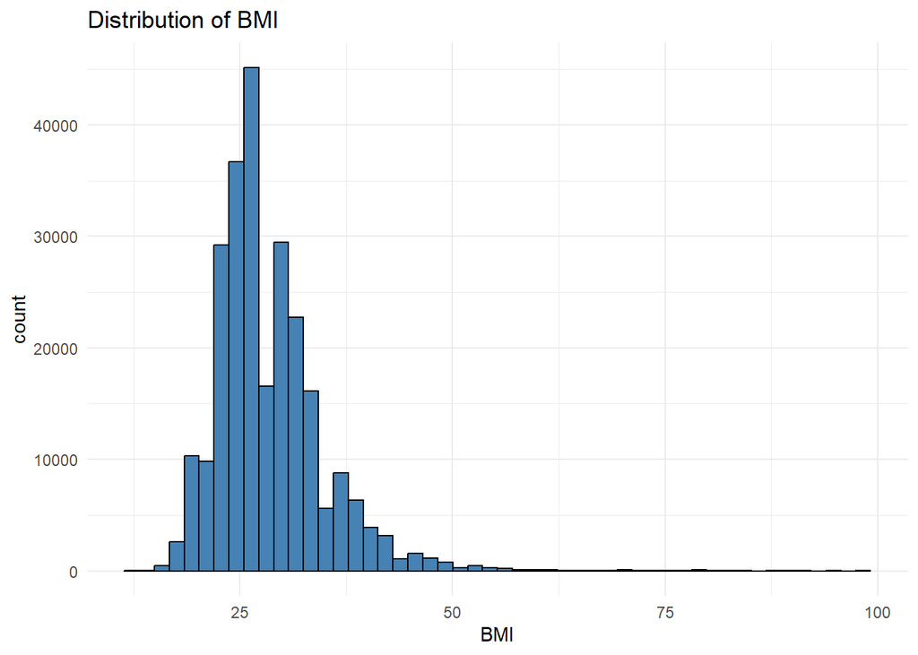

```r
ggplot(diabetes.df, aes(x = BMI)) +
  geom_histogram(bins = 50, fill = "steelblue", color = "black") +
  theme_minimal() + labs(title = "Distribution of BMI")
```

The histogram reveals the distribution of Body Mass Index (BMI) across the dataset. The shape of the distribution is noticeably right-skewed, with most values concentrated in the 25–30 range, which aligns with the clinical classification of being overweight. A substantial number of individuals fall between 20 and 40 BMI, while only a few cases extend beyond 60, which may represent extreme outliers or possible data entry anomalies. The steep peak and long tail suggest the need for data transformation, such as logarithmic or square root scaling, especially if the BMI variable is used in machine learning models sensitive to skewed distributions. In summary, the dataset reflects a population with a high incidence of overweight and obesity, a factor likely relevant to diabetes prediction.

### Boxplot of Age

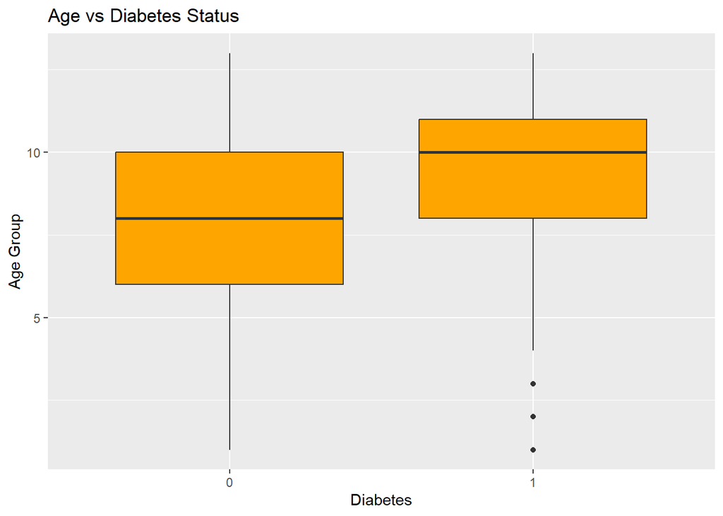

```r
ggplot(diabetes.df, aes(x = as.factor(Diabetes_binary), y = Age)) +
  geom_boxplot(fill = "orange") +
  labs(title = "Age vs Diabetes Status", x = "Diabetes", y = "Age Group")
```

The boxplot compares the age distribution (represented as age groups) between individuals with and without diabetes. From the visualization, it’s clear that those with diabetes tend to be older. The median age for non-diabetic individuals appears lower than for diabetic individuals, and the overall spread (interquartile range) is wider for the non-diabetic group. This suggests greater variability in the age of people without diabetes. Conversely, the diabetic group shows a more concentrated age range with a higher median, indicating that diabetes is more prevalent among older individuals. The presence of several lower-end outliers in the diabetic group also highlights that a small subset of younger individuals are affected. Overall, age appears to be a significant factor and potentially a strong predictor of diabetes in this dataset.

Remove outliers from Age within each Diabetes group

```r
diabetes.df <- diabetes.df %>%
  group_by(Diabetes_binary) %>%
  filter(
    Age > quantile(Age, 0.25) - 1.5 * IQR(Age) &
    Age < quantile(Age, 0.75) + 1.5 * IQR(Age)
  ) %>%
  ungroup()
```

The code removes outliers from the `Age` variable using the IQR method, applied separately within each diabetes group (`Diabetes_binary`). This group-wise filtering ensures that extreme age values are excluded based on the distribution of each group, resulting in a cleaner dataset (`diabetes.df`) for more accurate analysis, visualizations, and modeling.

### Correlation among numeric variables

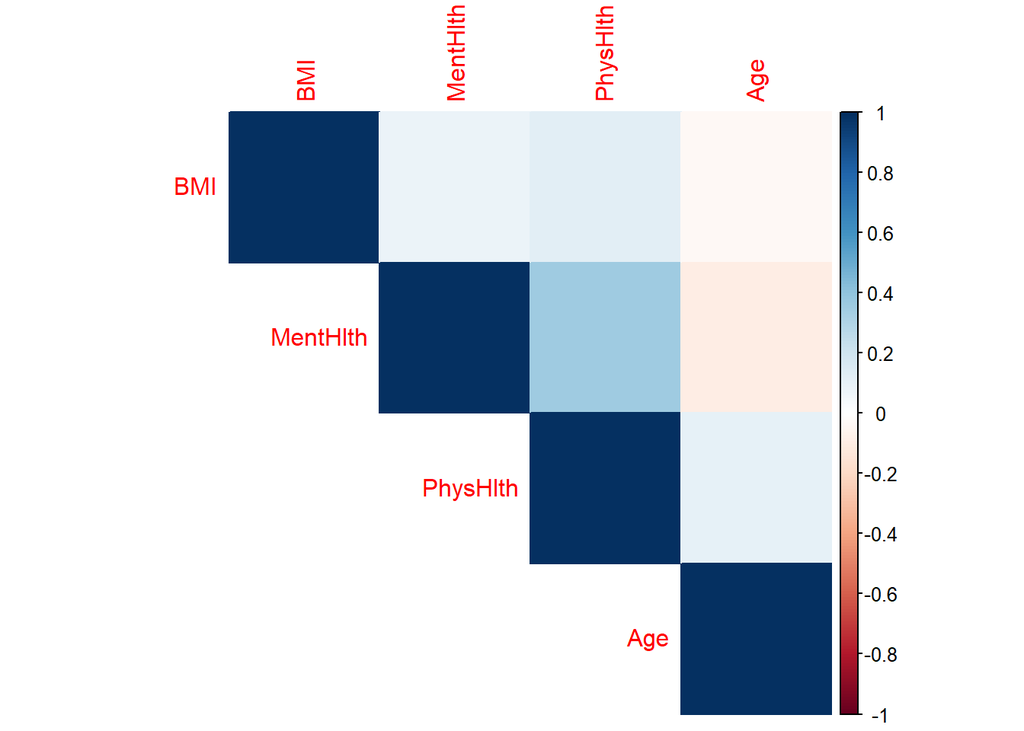

```r
numeric_vars <- diabetes.df %>% select(BMI, MentHlth, PhysHlth, Age)
corrplot(cor(numeric_vars), method = "color", type = "upper")
```

The correlation matrix provides insight into the linear relationships among four numeric variables: BMI, Mental Health (MentHlth), Physical Health (PhysHlth), and Age. The results show that there is minimal correlation between these variables. For instance, BMI shows very weak correlations with both mental and physical health days, and age exhibits only a modest positive correlation with physical health. This lack of strong multicollinearity suggests that these variables contribute independent information to the dataset and are not redundant. As such, each of them may be valuable in a predictive model for diabetes. However, the low pairwise correlations also indicate that any potential interactions or nonlinear effects should be explored through feature engineering or more complex modeling approaches.

### Handle duplicates

```r
diabetes.df <- distinct(diabetes.df)
dim(diabetes.df)
```

```
## [1] 228942     22
```

### Binning Mental and Physical Health

```r
diabetes.df$MentHlth_binned <- cut(diabetes.df$MentHlth,
                                   breaks = c(-1, 0, 10, 20, 30),
                                   labels = c("None", "Low", "Moderate", "High"))
diabetes.df$PhysHlth_binned <- cut(diabetes.df$PhysHlth,
                                   breaks = c(-1, 0, 10, 20, 30),
                                   labels = c("None", "Low", "Moderate", "High"))
```

The code bins the `MentHlth` and `PhysHlth` variables—representing the number of unhealthy days—into four categorical levels: “None,” “Low,” “Moderate,” and “High.” This simplifies analysis, improves interpretability, and supports visualizations or modeling, especially for skewed data. The binning enhances clarity but should be evaluated to ensure meaningful thresholds and balanced group sizes.

### Scale BMI

```r
diabetes.df$BMI_scaled <- scale(diabetes.df$BMI)
```

### Age Groups

```r
diabetes.df$Age_group <- cut(diabetes.df$Age,
                             breaks = c(0, 4, 8, 13),
                             labels = c("18–34", "35–54", "55+"))
```

### Feature Engineering:

#### Chronic Risk Load

```r
diabetes.df$Chronic_Risk_Load <- with(diabetes.df, HighBP + HighChol + Stroke + HeartDiseaseorAttack)
```

The `Chronic_Risk_Load` variable is a newly engineered feature that sums four binary health indicators—high blood pressure, high cholesterol, stroke, and heart disease—to reflect an individual’s total chronic disease burden. Ranging from 0 to 4, it provides a simplified, interpretable measure of health risk that can enhance predictive modeling and population stratification. This feature helps capture the compounded effect of comorbidities and supports deeper analysis of how chronic conditions relate to diabetes and other health outcomes.

#### Healthcare Barrier Index

```r
diabetes.df$Healthcare_Barrier_Index <- with(diabetes.df, NoDocbcCost + (1 - AnyHealthcare))
```

The `Healthcare_Barrier_Index` is a new feature that combines lack of insurance and inability to afford doctor visits into a single score ranging from 0 to 2. It captures the extent of healthcare access barriers, with higher values indicating greater difficulty in obtaining care. This index enhances analysis by incorporating structural health risk factors and can be used to examine how access issues relate to health outcomes like diabetes.

### Drop or convert unused columns

```r
data_prep <- diabetes.df %>%
  select(Diabetes_binary, BMI_scaled, MentHlth_binned, PhysHlth_binned, Age_group,
         Chronic_Risk_Load, Healthcare_Barrier_Index, GenHlth, Education, Income,
         Smoker, PhysActivity, DiffWalk, HvyAlcoholConsump, Sex)
```

### Convert other categorical to factor

```r
data_prep <- data_prep %>%
  mutate(across(where(is.character), as.factor),
         across(c(Diabetes_binary, GenHlth, Education, Income, Smoker, PhysActivity,
                  DiffWalk, HvyAlcoholConsump, Sex, Age_group,
                  MentHlth_binned, PhysHlth_binned), as.factor))
```

## Modeling

### Split data

```r
set.seed(123)
train_idx <- createDataPartition(data_prep$Diabetes_binary, p = 0.8, list = FALSE)
train <- data_prep[train_idx, ]
test <- data_prep[-train_idx, ]
```

### Logistic Regression (Baseline Model)

```r
model_logit <- glm(Diabetes_binary ~ ., data = train, family = binomial)
```

#### Model Summary

```r
summary(model_logit)
```

```
##
## Call:
## glm(formula = Diabetes_binary ~ ., family = binomial, data = train)
##
## Coefficients:
##                           Estimate Std. Error z value Pr(>|z|)
## (Intercept)              -4.993397   0.216186 -23.098  < 2e-16 ***
## BMI_scaled                0.397866   0.006798  58.531  < 2e-16 ***
## MentHlth_binnedLow       -0.137174   0.019223  -7.136 9.63e-13 ***
## MentHlth_binnedModerate  -0.108289   0.033828  -3.201 0.001369 **
## MentHlth_binnedHigh      -0.068448   0.029293  -2.337 0.019457 *
## PhysHlth_binnedLow       -0.024139   0.018231  -1.324 0.185479
## PhysHlth_binnedModerate  -0.076814   0.030895  -2.486 0.012909 *
## PhysHlth_binnedHigh      -0.131897   0.026970  -4.890 1.01e-06 ***
## Age_group35–54            1.594698   0.048406  32.944  < 2e-16 ***
## Age_group55+              2.040972   0.048489  42.091  < 2e-16 ***
## Chronic_Risk_Load         0.497762   0.007905  62.972  < 2e-16 ***
## Healthcare_Barrier_Index -0.066966   0.019173  -3.493 0.000478 ***
## GenHlth2                  0.715419   0.038583  18.542  < 2e-16 ***
## GenHlth3                  1.359769   0.037608  36.156  < 2e-16 ***
## GenHlth4                  1.774137   0.040570  43.731  < 2e-16 ***
## GenHlth5                  1.936296   0.047890  40.432  < 2e-16 ***
## Education2               -0.087799   0.210487  -0.417 0.676590
## Education3               -0.228796   0.208373  -1.098 0.272199
## Education4               -0.276832   0.206742  -1.339 0.180563
## Education5               -0.263316   0.206848  -1.273 0.203021
## Education6               -0.303692   0.206993  -1.467 0.142332
## Income2                   0.040504   0.040013   1.012 0.311404
## Income3                  -0.008966   0.038669  -0.232 0.816647
## Income4                  -0.007683   0.037880  -0.203 0.839269
## Income5                  -0.081050   0.037395  -2.167 0.030202 *
## Income6                  -0.151129   0.036940  -4.091 4.29e-05 ***
## Income7                  -0.182818   0.037398  -4.888 1.02e-06 ***
## Income8                  -0.256822   0.036976  -6.946 3.77e-12 ***
## Smoker1                  -0.042337   0.014939  -2.834 0.004597 **
## PhysActivity1            -0.033916   0.015983  -2.122 0.033837 *
## DiffWalk1                 0.134718   0.018795   7.168 7.62e-13 ***
## HvyAlcoholConsump1       -0.838346   0.044188 -18.972  < 2e-16 ***
## Sex1                      0.241831   0.015152  15.960  < 2e-16 ***
## ---
## Signif. codes:  0 '***' 0.001 '**' 0.01 '*' 0.05 '.' 0.1 ' ' 1
##
## (Dispersion parameter for binomial family taken to be 1)
##
##     Null deviance: 155461  on 183153  degrees of freedom
## Residual deviance: 124588  on 183121  degrees of freedom
## AIC: 124654
##
## Number of Fisher Scoring iterations: 6
```

#### Predict probabilities and classes

```r
test_probs <- predict(model_logit, newdata = test, type = "response")
test_pred <- ifelse(test_probs > 0.5, 1, 0)
```

#### Confusion Matrix

```r
confusionMatrix(as.factor(test_pred), test$Diabetes_binary, positive = "1")
```

```
## Confusion Matrix and Statistics
##
##           Reference
## Prediction     0     1
##          0 38038  5875
##          1   837  1038
##
##                Accuracy : 0.8534
##                  95% CI : (0.8501, 0.8566)
##     No Information Rate : 0.849
##     P-Value [Acc > NIR] : 0.004318
##
##                   Kappa : 0.1836
##
##  Mcnemar's Test P-Value : < 2.2e-16
##
##             Sensitivity : 0.15015
##             Specificity : 0.97847
##          Pos Pred Value : 0.55360
##          Neg Pred Value : 0.86621
##              Prevalence : 0.15098
##          Detection Rate : 0.02267
##    Detection Prevalence : 0.04095
##       Balanced Accuracy : 0.56431
##
##        'Positive' Class : 1
##
```

#### ROC Curve

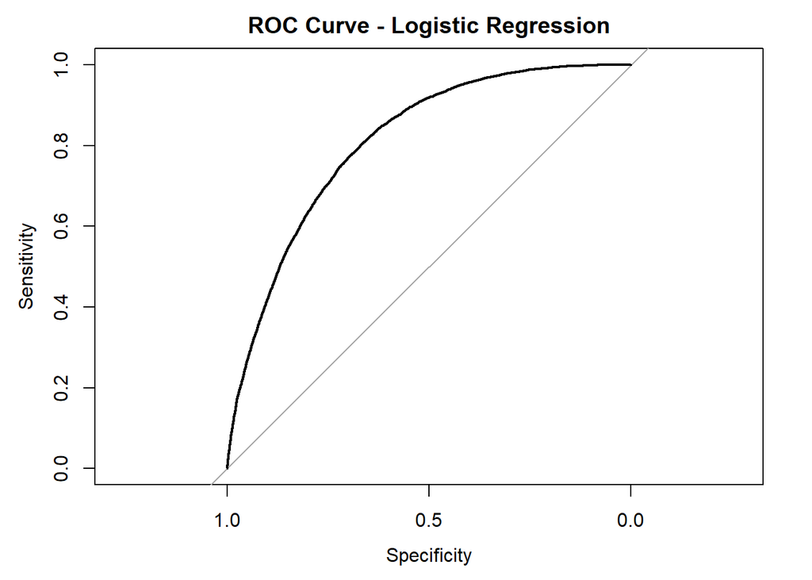

```r
library(pROC)
roc_obj <- roc(test$Diabetes_binary, test_probs)
plot(roc_obj, main = "ROC Curve - Logistic Regression")
```

```r
auc(roc_obj)
```

```
## Area under the curve: 0.8092
```

## Deployment

## References